# Titanic Kaggle

## 4.4 Ticket -> ticket.size

‘Chapter 3.1.3 Summary()’ 확인 결과 승객은(‘train’, ‘test’합쳐서 모두) 1309명이다. 하지만 티켓은 모두 달라야 하지만 그렇지 않다. ’summary()’와 ’unique()’ 결과값을 확인하자

```r
# 'unique'한 범주의 갯수만 파악하려고 length()를 사용
length(unique(full$Ticket))
```

```
## [1] 929
```

```r
# 모두 출력하면 지저분하니 10개만 출력
head(summary(full$Ticket), 10)
```

```
##     CA. 2343         1601      CA 2144      3101295       347077
##           11            8            8            7            7
##       347082     PC 17608 S.O.C. 14879       113781        19950
##            7            7            7            6            6
```

결측치가 없는 ’feature’인데 unique한 티켓이 929개 뿐이다. ’CA. 2343’인 티켓은 11명이나 같다. 어떤 승객들인지 확인해보자.

```r
full %>%
  # 티켓이 일치하는 11명의 승객들 필터링
  filter(Ticket == 'CA. 2343') %>%
  # 몇 가지 변수 확인
  select(Pclass, Name, Age, FamilySized)
```

```
## # A tibble: 11 x 4
##    Pclass Name                                    Age FamilySized
##    <ord>  <fct>                                 <dbl> <fct>
##  1 3      Sage, Master. Thomas Henry             29.9 Big
##  2 3      Sage, Miss. Constance Gladys           29.9 Big
##  3 3      Sage, Mr. Frederick                    29.9 Big
##  4 3      Sage, Mr. George John Jr               29.9 Big
##  5 3      Sage, Miss. Stella Anna                29.9 Big
##  6 3      Sage, Mr. Douglas Bullen               29.9 Big
##  7 3      "Sage, Miss. Dorothy Edith \"Dolly\""  29.9 Big
##  8 3      Sage, Miss. Ada                        29.9 Big
##  9 3      Sage, Mr. John George                  29.9 Big
## 10 3      Sage, Master. William Henry            14.5 Big
## 11 3      Sage, Mrs. John (Annie Bullen)         29.9 Big
```

이 티켓의 11명은 모두 같은 가족 & 형제인 것을 알 수 있다. 티켓이 완전히 동일한 승객들이 있는 반면 일부분만 일치하는 승객들도 있다. 티켓의 Unique 넘버 갯수를 나타내는 ‘ticket.unique’ 파생변수를 만들고, ‘ticket.unique’를 바탕으로 3개 범주를 갖는 ’ticket.size’ 파생변수도 만든다.

```r
# ticket.unique가 모두 0이라고 저장
ticket.unique <- rep(0, nrow(full))

# Ticket Feature에서 unique한 것들만 추출해서 tickets 벡터에 저장
tickets <- unique(full$Ticket)

# 반복문을 중첩 활용해서 티켓이 같은 승객들만 선별 후, 각 티켓의 길이를 추출하여 저장
for (i in 1:length(tickets)) {
  current.ticket <- tickets[i]
  party.indexes <- which(full$Ticket == current.ticket)
    # For loop 중첩
    for (k in 1:length(party.indexes)) {
      ticket.unique[party.indexes[k]] <- length(party.indexes)
    }
  }

# 위에서 계산한 ticket.unique를 파생변수로 저장
full$ticket.unique <- ticket.unique

# ticket.unique에 따라 세가지 범주로 나눠서 ticket.size 변수 생성
full <- full %>%
  mutate(ticket.size = case_when(ticket.unique == 1 ~ 'Single',
                                 ticket.unique < 5 & ticket.unique >= 2 ~ 'Small',
                                 ticket.unique >= 5 ~ 'Big'),
         ticket.size = factor(ticket.size,
                              levels = c('Single','Small','Big')))
```

## 4.5 Embarked

결측치가 2개 있던 ’feature’임 ’Embarked’의 경우 3개 범주 중에서 가장 최반값인 ’S’로 치환

```r
full$Embarked <- replace(full$Embarked,               # 치환할 Data$feature 지정
                         which(is.na(full$Embarked)), # 결측치 찾기
                         'S')                         # 치환할 값 지정
```

## 4.6 Fare

’Fare’의 경우 결측치가 유일하게 1개임 ’Chapter 3.5 Fare’를 바탕으로 결측치를 0으로 치환

```r
full$Fare <- replace(full$Fare, which(is.na(full$Fare)), 0)
```

– 데이터 전처리 완료– 이후, 지금까지 만든 파생변수들을 탐색하며 모델 생성에 사용할 변수 선별 ‘Feature selection’

# 5 Relationship to target feature ‘Survived’ & Feature selection

각 변수와 생존율간 연관성 파악. ‘test’는 생존.사망이 NA기 때문에 제외하고, 생존과 사망 여부를 알 수 있는 ’train’ data set만 사용함

## 5.1 Data set split

전처리 끝난 ‘full’ data를 ‘train’, ’test’로 분할

```r
# feature selection 전이므로 모든 변수들을 선택
train <- full[1:891, ]

test <- full[892:1309, ]
```

## 5.2 Pclass

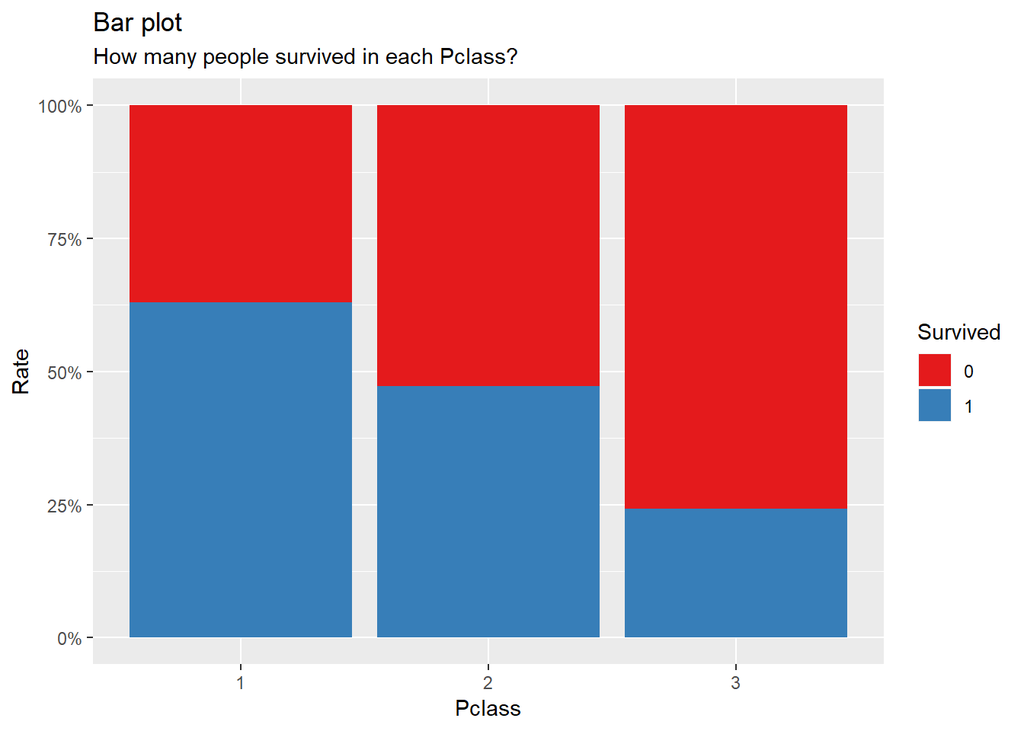

```r
train %>%
  ggplot(aes(Pclass, fill = Survived)) +
  geom_bar(position = 'fill') +
  # plot 테마 설정 : 조금 더 선명한 색깔로 변환
  scale_fill_brewer(palette = 'Set1')  +
  # Y axis setting
  scale_y_continuous(labels = percent) +
  # x, y 축 이름과 plot의 main title, sub title 설정
  labs(x = 'Pclass', y = "Rate",
       title = "Bar plot", subtitle = 'How many people survived in each Pclass?')
```

## 5.3 Sex

** ‘Chapter 3.6 Sex와 동일’ **

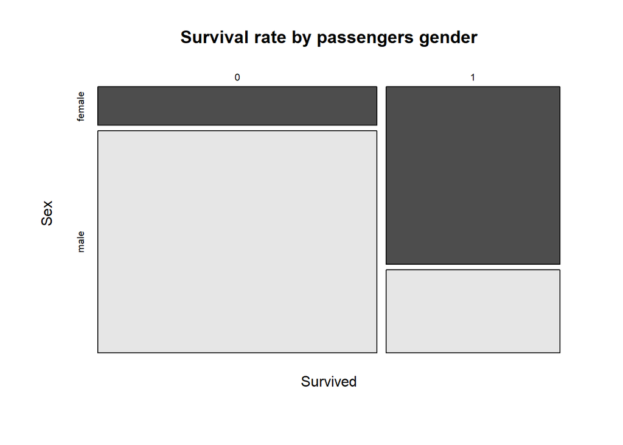

```r
mosaicplot(Survived ~ Sex,
           data = train, col = TRUE,
           main = 'Survival rate by passengers gender')
```

## 5.4 Embarked

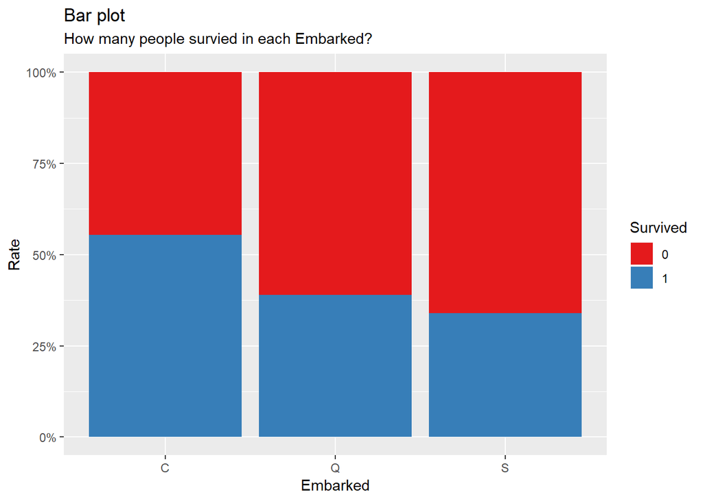

```r
train %>%
  ggplot(aes(Embarked, fill = Survived)) +
  geom_bar(position = 'fill') +
  scale_fill_brewer(palette = 'Set1') +
  scale_y_continuous(labels = percent) +
  labs(x = 'Embarked', y = 'Rate',
       title = 'Bar plot', subtitle = 'How many people survied in each Embarked?')
```

## 5.5 FamilySized

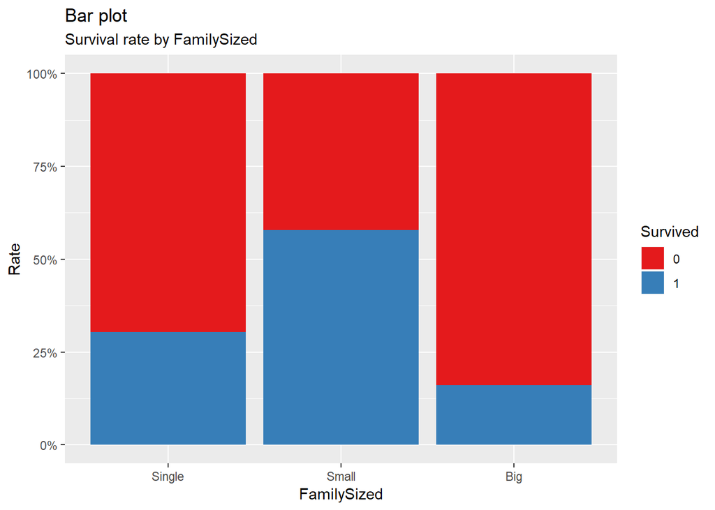

```r
train %>%
  ggplot(aes(FamilySized, fill = Survived)) +
  geom_bar(position = 'fill') +
  scale_fill_brewer(palette = 'Set1') +
  scale_y_continuous(labels = percent) +
  labs(x = "FamilySized", y = 'Rate',
       title = 'Bar plot', subtitle = 'Survival rate by FamilySized')
```

동승한 인원수에 따라 생존율에 차이가 있고, ’FamilySized’와 ’Survived’는 비선형 관계임을 알 수 있다.

## 5.6 Age.Group

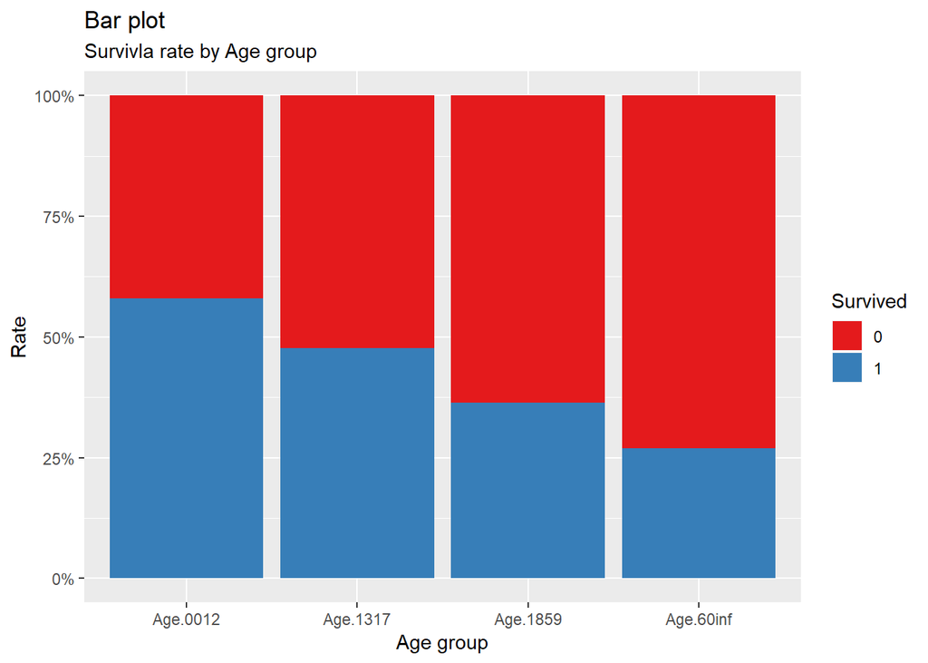

```r
train %>%
  ggplot(aes(Age.Group, fill = Survived)) +
  geom_bar(position = 'fill') +
  scale_fill_brewer(palette = 'Set1') +
  scale_y_continuous(labels = percent) +
  labs(x = 'Age group', y = 'Rate',
       title = 'Bar plot', subtitle = 'Survivla rate by Age group')
```

## 5.7 title

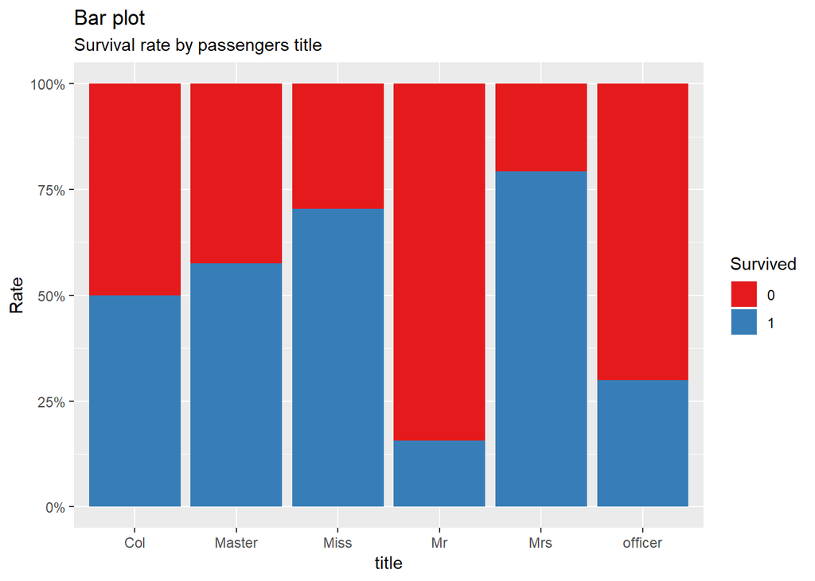

```r
train %>%
  ggplot(aes(title, fill = Survived)) +
  geom_bar(position = 'fill') +
  scale_fill_brewer(palette = 'Set1') +
  scale_y_continuous(labels = percent) +
  labs(x = 'title', y = 'Rate',
       title = 'Bar plot', subtitle = 'Survival rate by passengers title')
```

## 5.8 ticket.size

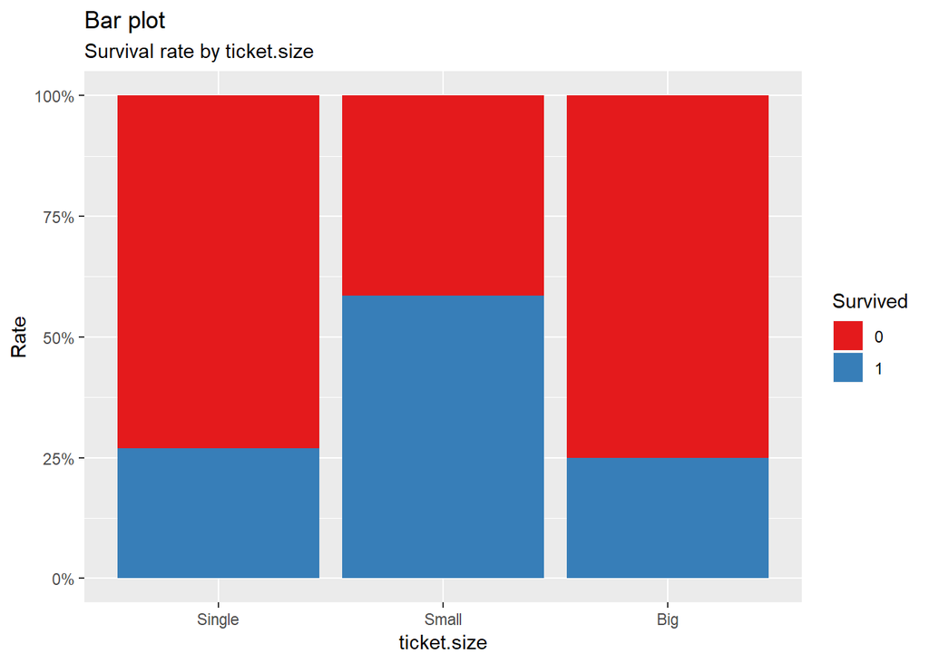

```r
train %>%
  ggplot(aes(ticket.size, fill = Survived)) +
  geom_bar(position = 'fill') +
  scale_fill_brewer(palette = 'Set1') +
  scale_y_continuous(labels = percent) +
  labs(x = 'ticket.size', y = 'Rate',
       title = 'Bar plot', subtitle = 'Survival rate by ticket.size')
```

## 5.9 Description of actual used features

생성한 파생변수들의 유효성을 확인했으니, 실제로 사용할 변수들만 선별해서 저장. 실제 선택한 변수들에 대한 간단한 설명

[output not shown]

```r
# Id number 제외하고 실제로 사용할 7개 입력 변수와 1개 타겟 변수를 선택, 저장
train <- train %>%
  select('Pclass', 'Sex', 'Embarked', 'FamilySized', 'Age.Group', 'title',
         'ticket.size', 'Survived')

# Submit을 위해 Id 열 추출하여 ID에 저장
ID <- test$PassengerId

# Id와 Survived를 제외한 나머지 6개 변수 선택, 저장
test <- test %>%
  select('Pclass', 'Sex', 'Embarked', 'FamilySized', 'Age.Group','title','ticket.size')
```

# 6 Machine learning model generation

‘train’ data set으로 기계학습 ‘train’, ‘validation’, ‘test’로 교차검증(’Cv’)으로 선택을 하는게 맞지만,여기서는 ‘RandomForest’만을 생성하여 ’test’ data를 예측하고 ’Submit’용 data까지만 생성.

## 6.1 Random Forest model generation

```r
# 재현성을 위해 seed number를 설정
set.seed(1901)

titanic.rf <- randomForest(Survived ~ ., data = train, importance = T, ntree = 2000)
```

## 6.2 Feature importance check

```r
importance(titanic.rf)
```

```
##                     0        1 MeanDecreaseAccuracy MeanDecreaseGini
## Pclass      48.064732 55.31568             67.28920        37.485941
## Sex         51.578437 35.25159             55.65668        52.964241
## Embarked    -6.508585 34.61697             25.25949         9.178969
## FamilySized 32.340175 30.32503             49.78611        17.975488
## Age.Group   13.612591 26.62673             27.85438        10.103775
## title       49.855871 43.81056             59.36445        77.800504
## ticket.size 40.067927 39.48394             61.32680        22.520265
```

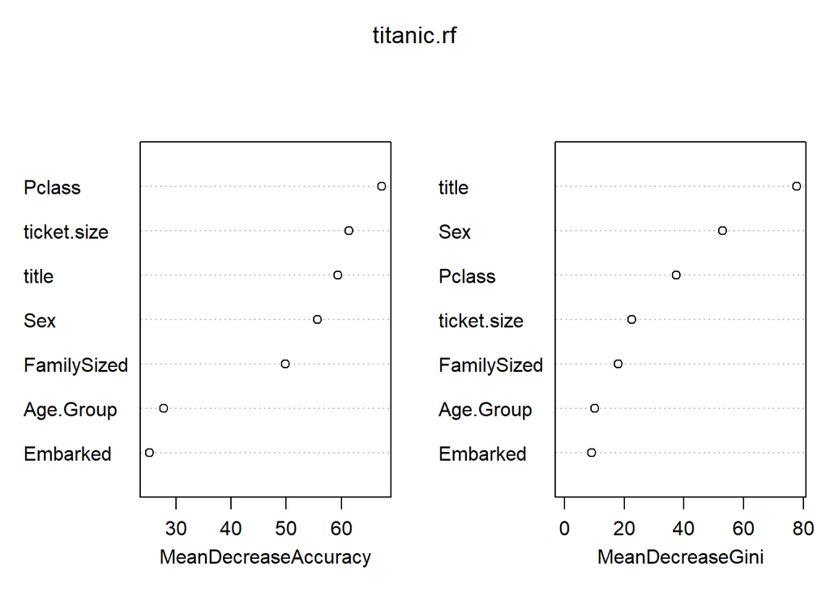

```r
varImpPlot(titanic.rf)
```

## 6.3 Predict test data and create submit data

```r
# Prediction
pred.rf <- predict(object = titanic.rf, newdata = test, type = "class")

# Data frame generation
submit <-  data.frame(PassengerID = ID, Survived = pred.rf)

# Write the submit data frame to file: setwd()로 지정해놓은 폴더에 csv로 생성됨.
write.csv(submit, file = './titanic_submit.csv', row.names = F)
```

– 완 –

# 7 Reference : 참고문헌

1. [‘Megan Risdal’ titanic kernel](https://www.kaggle.com/mrisdal)
2. [‘Heads or Tails’ titanic kernel](https://www.kaggle.com/headsortails)
3. [Hitesh palamada - Head Start for Data Scientist](https://www.kaggle.com/hiteshp/head-start-for-data-scientist)
4. [나무위키 - RMS 타이타닉](https://namu.wiki/w/RMS%20%ED%83%80%EC%9D%B4%ED%83%80%EB%8B%89)
5. R을 활용한 데이터 과학(인사이트), Garrett Grolemund, Hadley Wickham 지음, 김설기, 최혜민 옮김, 978-89-6626-235-9 : tidyverse를 이해하기 가장 좋은 책
6. [tidyr::gather() - Software Carpentry](https://statkclee.github.io/r-novice-gapminder/14-tidyr-kr.html)
7. 머신러닝 탐구생활(비제이퍼블릭), 정권우 지음, 979-11-86697-69-6 : Data 분석 노트(표) 작성하는데 많은 도움을 받았습니다.

# 8 원문 링크

https://www.kaggle.com/redhorse93/r-titanic-data